# Data science per psicologi - demo 18.02

Corrado Caudek

2022-03-11

```r
suppressPackageStartupMessages({
  library("here")
  library("tidyverse")
  library("scales")
  library("bayesplot")
  library("rstan")
  library("cmdstanr")
  library("posterior")
  library("loo")
  library("rethinking")
  library("brms")
  library("dagitty")
  library("ggdag")
})

rstan_options(auto_write = TRUE) # avoid recompilation of models
options(mc.cores = parallel::detectCores()) # parallelize across all CPUs
Sys.setenv(LOCAL_CPPFLAGS = "-march=native") # improve execution time

theme_set(bayesplot::theme_default(base_size = 12))
bayesplot::color_scheme_set("gray")
set.seed(84735)

knitr::opts_chunk$set(
  collapse = TRUE,
  # tidy = 'styler',
  fig.width = 6,
  fig.asp = 0.618 # 1 / phi
)
```

# Stima dei coefficienti e rumore

In questo tutorial viene esaminato un aspetto discusso da Richard McElreath nella sua lecture [Statistical Rethinking 2022 Lecture 17](https://www.youtube.com/watch?v=lTFAB6QmwHM&list=PLDcUM9US4XdMROZ57-OIRtIK0aOynbgZN&index=18). Con una semplice simulazione, McElreath mostra come la presenza di rumore non produce sempre una sottostima dei “veri” effetti causali. L’idea diffusa è che le stime delle associazioni tra variabili che otteniamo nelle analisi dei dati rappresentano sempre, a causa del rumore intrinseco nelle misurazioni, delle sottostime dei veri effetti causali che sono presenti nel mondo empirico. Una tale sottostima è chiamata *attenuazione*. Ma questa idea è falsa. Con questa semplice simulazione, McElreath mostra come, in generale, la presenza di rumore di misurazione non comporta necessariamente una sottostima degli effetti causali che legano le variabili.

McElreath ipotizza la seguente struttura causale nella quale $x$ ha un effetto su $y$. Come sempre avviene in pratica, il ricercatore non ha un accesso diretto a $x$ ma può misurare solo un qualche proxy di $x$, qui chiamato $x_{star}$. La variabile misurata, necessariamente, risulta corrotta dal rumore $e$. McElreath ipotizza, come avviene spesso in pratica, che l’entità del rumore che influenza $x_{star}$ dipenda da $y$. La situazione è rappresentata dal seguente diagramma:

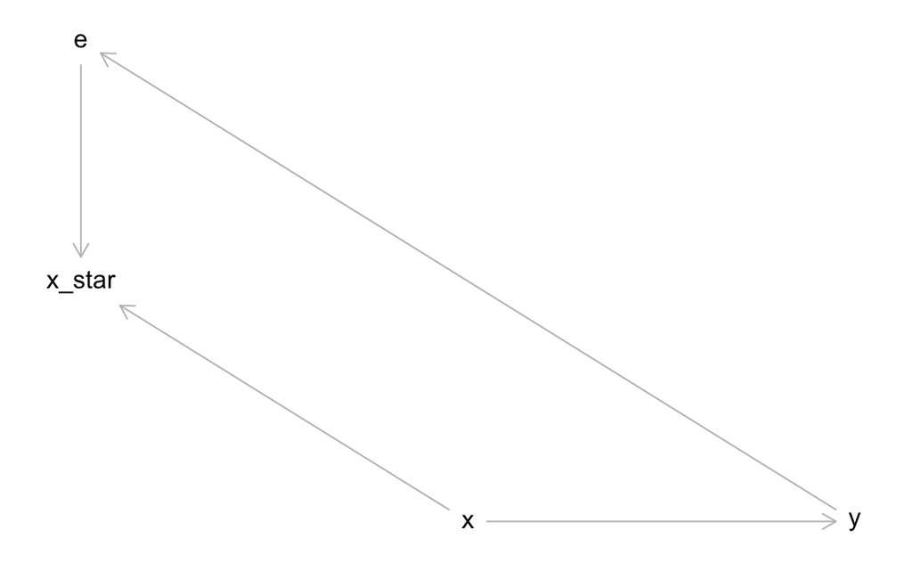

```r
dag <- dagitty("dag {
  x -> x_star
  x -> y
  e -> x_star
  y -> e
}")

coordinates(dag) <- list(
  x = c(e = 1, x = 2, x_star = 1, y = 3),
  y = c(e = 1, x = 3, x_star = 2, y = 3)
)
plot(dag)
```

Simuliamo ora un campione di dati che soddisfa i vincoli di una tale struttura causale:

```r
n <- 500
x <- rnorm(n)
y <- rnorm(n, 0.0 * x)
x_star <- rnorm(n, 0.7*x + 0.3*y)
```

Si noti che, nella struttura causale ipotizzata, i dati sono stati generati assumendo che $x$ abbia un effetto nullo sulla $y$.

Inseriamo i dati in una lista appropriata come input per Stan:

```r
data_list <- list(
  N = length(x),
  x = x_star,
  y = y
)
```

Utilizziamo un semplice modello di regressione per esaminare la relazione tra $x$ e $y$ in questi dati.

```r
modelString = "
data {
  int<lower=0> N;
  vector[N] x;
  vector[N] y;
}
parameters {
  real alpha;
  real beta;
  real<lower=0> sigma;
}
model {
  alpha ~ normal(0, 1);
  beta ~ normal(0, 1);
  sigma ~ exponential(1);
  y ~ normal(alpha + beta * x, sigma);
}
"
writeLines(modelString, con = "code/noise_1.stan")
```

Leggiamo il file in cui abbiamo salvato il codice Stan

```r
file <- file.path("code", "noise_1.stan")
```

Compiliamo il modello

```r
mod <- cmdstan_model(file)
```

Eseguiamo il campionamento MCMC:

```r
fit <- mod$sample(
  data = data_list,
  iter_sampling = 4000L,
  iter_warmup = 2000L,
  seed = 84735,
  chains = 4L,
  refresh = 0,
  thin = 1
)
```

Esaminiamo la soluzione trasformando l’oggetto `fit` nel formato `stanfit` per comodità:

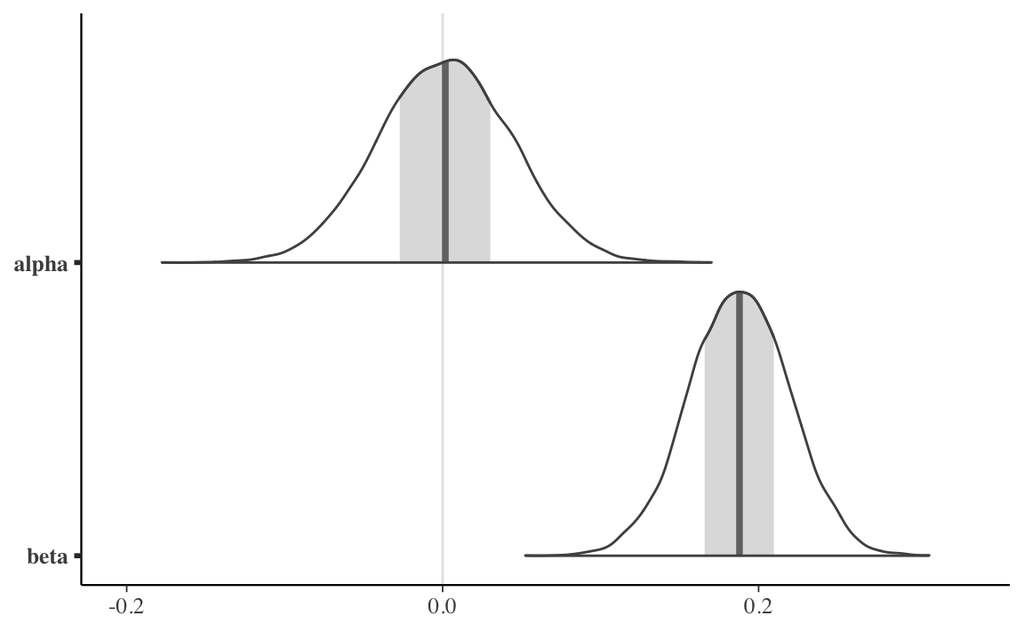

```r
stanfit <- rstan::read_stan_csv(fit$output_files())
posterior <- as.matrix(stanfit)
mcmc_areas(posterior, pars = c("alpha", "beta"))
```

Esaminiamo ora la situazione opposta, ovvero quella nella quale vi è un effetto causale di $x$ sulla $y$. Simuliamo i dati seguendo le indicazioni di McElreath:

```r
n <- 500
x <- rnorm(n)
y <- rnorm(n, 0.8 * x)
x_star <- rnorm(n, 0.7*x + 0.3*y)
```

Inseriamo i dati in una lista:

```r
data2_list <- list(
  N = length(x),
  x = x_star,
  y = y
)
```

Eseguiamo il campionamento MCMC:

```r
fit2 <- mod$sample(
  data = data2_list,
  iter_sampling = 4000L,
  iter_warmup = 2000L,
  seed = 84735,
  chains = 4L,
  refresh = 0,
  thin = 1
)
```

Esaminiamo la soluzione ottenuta:

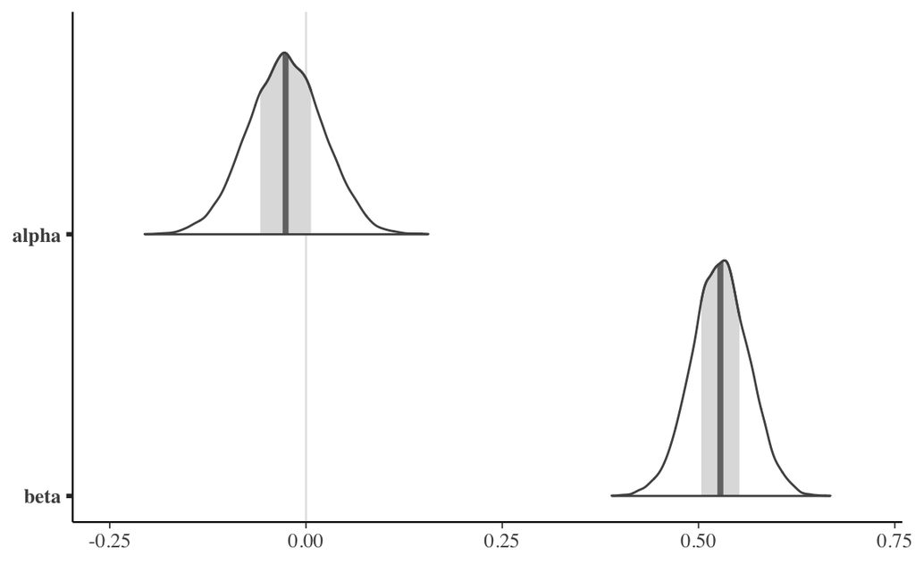

```r
stanfit2 <- rstan::read_stan_csv(fit2$output_files())
posterior2 <- as.matrix(stanfit2)
mcmc_areas(posterior2, pars = c("alpha", "beta"))
```

In questo secondo caso, il vero effetto causale è $\beta = 0.8$ ma, a causa del rumore di misurazione, abbiamo stimato $\hat{\beta} \approx 0.5$.

In conclusione, la presenza del rumore di misurazione può avere effetti opposti: può fare emergere un’associazione causale che, in realtà, non esiste, oppure può sottostimare un’associazione causale effettiva. Il risultato che si osserva dipende dalla reale struttura causale che lega le variabili.